# Récoltes et Semailles

Lessons to Learn from a Life

Author

Ali ALMASI

Published

February 4, 2025

[RS (en.)](https://web.ma.utexas.edu/users/slaoui/notes/recoltes_et_semailles.pdf), Section 2.1:

> When I was little, I liked going to school. The same teacher taught us reading, writing, arithmetic, and singing (he accompanied us with a small violin), and he even told us about prehistoric men and the discovery of fire. I do not ever recall being bored at school during those days. There was the magic of numbers, that of words, of signs, and of sounds. That of rhymes as well, through songs and small poems. There seemed to be, within rhymes, a mystery that extended beyond words. I believed this until the day somebody told me that there was a simple “trick” to it—that rhyme was simply when one ends two consecutive spoken movements with the same syllable, so that, as if by magic, these phrases became verses. It was a revelation!

> At home, where I found a good audience, I amused myself for weeks or months on end by making verses. At one point, I even started exclusively speaking in rhymes. That period has passed, fortunately. Yet even to this day, I still sometimes write poems—but without trying to force the rhyme if it doesn’t seem to come by itself.

> On another occasion, an older friend who was already in high school taught me about negative numbers. It was also a fun game, although I rapidly exhausted it. And then there were crosswords—I spent days and weeks constructing them, ever more interwoven. Within that game, the magic of form, that of signs, and that of words found themselves combined. But even that passion subsided without leaving a trace.

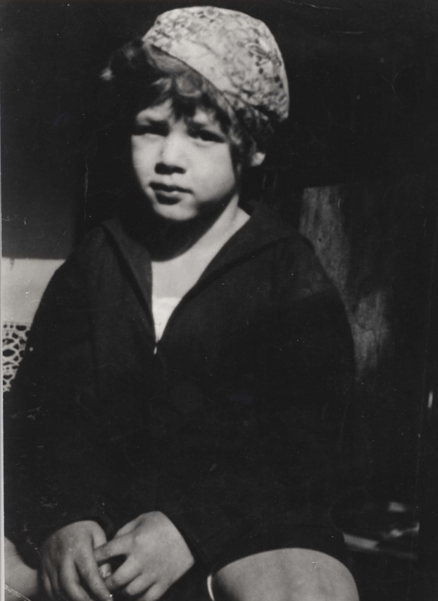

[RS (en.)](https://web.ma.utexas.edu/users/slaoui/notes/recoltes_et_semailles.pdf), Section 2.1:

> I still remember my first “math examination,” in which the teacher gave me a bad grade for my proof of one of the “three cases of equality of triangles.” My proof wasn’t exactly that of the book, which he followed religiously. Yet, I knew very well that my proof was no less convincing than that of the book, which I followed in spirit through repeated invocation of the traditional “we slide this figure in such and such a way onto that figure.” Visibly, this teacher did not feel capable of judging things—namely, the validity of my reasoning—on his own. He had to report to a higher authority, that of a book in this case. Since I still remember this incident, I must have been struck by such dispositions. In the years that followed, I was presented with more than enough evidence to realize that such dispositions are far from exceptional—rather, they are the quasi-universal norm…

> I spent a fair amount of time, including class time (shh…), solving math problems. The ones in the book soon became insufficient—perhaps because they started to resemble one another after a while, but mostly, I believe, because they seemed to come out of the blue à la queue-leu-leu, with no indication of where they came from or where they were going. These were the book’s problems, not mine.

> And yet, natural questions were plentiful. For instance, once the three side lengths a, b, and c of a triangle are known—so that the triangle itself is determined (up to its position)—there must be an explicit formula that expresses the area of the triangle as a function of a, b, and c. Likewise, for a tetrahedron in which the six side lengths are known, what is the volume? I struggled with that one for a bit, but I must have gotten there eventually.

> In any case, when a problem grabbed me, I did not count the hours or days I spent working on it, even if it meant losing track of everything else! (And such remains the case to this day…)…

> What I found least satisfying in our math textbooks was the absence of a serious definition of the notion of length (of a curve), area (of a surface), or volume (of a solid). I promised myself to make up for this omission as soon as I could…